# Lab6

## **Lab 06 - Text Mining**

## **Learning goals**

- Use `unnest_tokens()` and `unnest_ngrams()` to extract tokens and ngrams from text.
- Use dplyr and ggplot2 to analyze text data

# **Lab description**

For this lab we will be working with a new dataset. The dataset contains transcription samples from https://www.mtsamples.com/. And is loaded and "fairly" cleaned at https://raw.githubusercontent.com/USCbiostats/data-science-data/master/00_mtsamples/mtsamples.csv.

### **read in Medical Transcriptions**

Loading in reference transcription samples from https://www.mtsamples.com/

```r
library(readr)
library(dplyr)
mt_samples <- read_csv("https://raw.githubusercontent.com/USCbiostats/data-science-data/master/00_mtsamples/mtsamples.csv")
mt_samples <- mt_samples %>%
  select(description, medical_specialty, transcription)

head(mt_samples)
```

```
# A tibble: 6 × 3
  description                                    medical_specialty transcription
  <chr>                                          <chr>             <chr>
1 A 23-year-old white female presents with comp… Allergy / Immuno… "SUBJECTIVE:…
2 Consult for laparoscopic gastric bypass.       Bariatrics        "PAST MEDICA…
3 Consult for laparoscopic gastric bypass.       Bariatrics        "HISTORY OF …
4 2-D M-Mode. Doppler.                           Cardiovascular /… "2-D M-MODE:…
5 2-D Echocardiogram                             Cardiovascular /… "1.  The lef…
6 Morbid obesity.  Laparoscopic antecolic anteg… Bariatrics        "PREOPERATIV…
```

## **Question 1: What specialties do we have?**

We can use `count()` from `dplyr` to figure out how many different catagories do we have? Are these catagories related? overlapping? evenly distributed?

```r
diff_cat <- mt_samples %>%
  group_by(medical_specialty) %>%
  summarize(count = n())
print(diff_cat, n = 40)
```

```
# A tibble: 40 × 2
   medical_specialty             count
   <chr>                         <int>
 1 Allergy / Immunology              7
 2 Autopsy                           8
 3 Bariatrics                       18
 4 Cardiovascular / Pulmonary      372
 5 Chiropractic                     14
 6 Consult - History and Phy.      516
 7 Cosmetic / Plastic Surgery       27
 8 Dentistry                        27
 9 Dermatology                      29
10 Diets and Nutritions             10
11 Discharge Summary               108
12 ENT - Otolaryngology             98
```

[output cut: 28 more lines]

The categories are not evenly distributed at all, there are some in single digits and some over 200. I feel like general medicine and surgery can overlap with some of these categories, especially surgery as many of the count were probably counted twice from whichever department of care they came from, maybe even more than that if they were admitted to the emergency room with a cardiac surgeon and then needed a cardiac surgeon to provide help and treatment. The “letters” one is something I am not familiar with and when I looked it up, I could not find what it meant either.

## **Question 2**

- Tokenize the the words in the `transcription` column
- Count the number of times each token appears
- Visualize the top 20 most frequent words

Explain what we see from this result. Does it makes sense? What insights (if any) do we get?

```r
library(ggplot2)
library(tidyr)
library(tidytext)
library(stringr)
TOKwords <- mt_samples %>%
  unnest_tokens(word, transcription)
count <- TOKwords %>%
  group_by(word) %>%
  summarize(count = n()) %>%
  arrange(desc(count))
toptwenty <- count %>%
  top_n(20)
print(toptwenty)
```

```
# A tibble: 20 × 2
   word     count
   <chr>    <int>
 1 the     149888
 2 and      82779
 3 was      71765
 4 of       59205
 5 to       50632
 6 a        42810
 7 with     35815
 8 in       32807
 9 is       26378
10 patient  22065
11 no       17874
12 she      17593
13 for      17049
14 he       15542
15 were     15535
16 on       14694
17 this     13949
18 at       13492
19 then     12430
20 right    11587
```

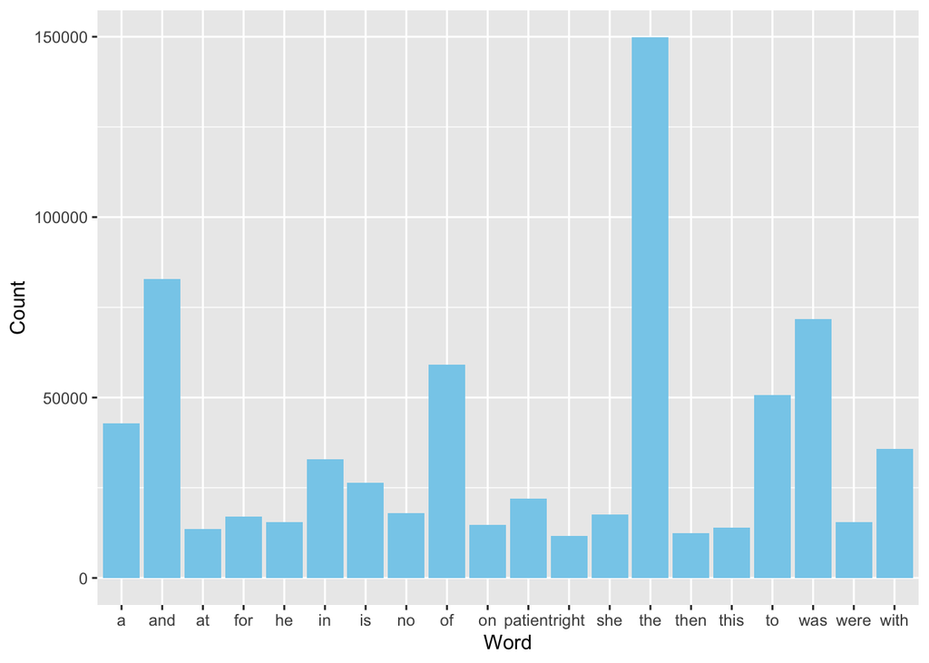

```r
ggplot(toptwenty, aes(x = word, y = count)) +
     geom_bar(stat = "identity", fill = "skyblue") +
     labs(x = "Word", y = "Count")
```

The words “the” and “and” and the rest of the top 9 are all conjunction words. Gender “she/he” were prevalent as well in addition to the word “patient”. It makes sense the word “patient” showing up but the conjunction words should be removed as they do not mean anything when trying to find a pattern or something.

## **Question 3**

- Redo visualization but remove stopwords before
- Bonus points if you remove numbers as well

What do we see know that we have removed stop words? Does it give us a better idea of what the text is about?

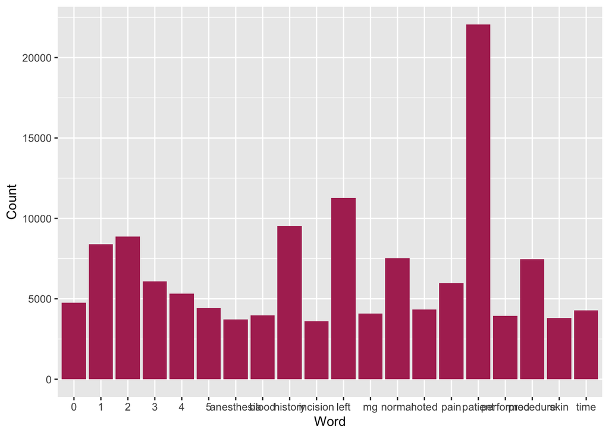

```r
newtoke <- mt_samples %>%
  mutate(transcription = tolower(transcription)) %>%
  unnest_tokens(word, transcription) %>%
  anti_join(stop_words)
newword_counts <- newtoke %>%
  count(word, sort = TRUE)
nostoplist <- newword_counts %>%
  top_n(20)
ggplot(nostoplist, aes(x = word, y = n)) +
     geom_bar(stat = "identity", fill = "maroon") +
     labs(x = "Word", y = "Count")
```

Yes, looks like a patient got a surgery done on them and it was performed with anesthesia and there were incisions done on the skin and blood appeared. They kept note of the time as well. We don’t know the whole story but it is a lot more clear than before these words were removed.

# **Question 4**

repeat question 2, but this time tokenize into bi-grams. how does the result change if you look at tri-grams?

```r
bigrams <- mt_samples %>%
  mutate(transcription = tolower(transcription)) %>%
  unnest_tokens(bigram, transcription, token = "ngrams", n = 2) %>%
  separate(bigram, into = c("word1", "word2"), sep = " ")
bigramcount <- bigrams %>%
  count(word1, word2, sort = TRUE)
bigramlist <- bigramcount %>%
  top_n(20)
trigrams <- mt_samples %>%
  mutate(transcription = tolower(transcription)) %>%
  unnest_tokens(bigram, transcription, token = "ngrams", n = 3) %>%
  separate(bigram, into = c("word1", "word2", "word3"), sep = " ")
trigramcount <- trigrams %>%
  count(word1, word2, word3, sort = TRUE)
trigramlist <- trigramcount %>%
  top_n(20)
print(bigramlist, n =20)
```

```
# A tibble: 20 × 3
   word1   word2       n
   <chr>   <chr>   <int>
 1 the     patient 20307
 2 of      the     19062
 3 in      the     12790
 4 to      the     12374
 5 was     then     6956
 6 and     the      6350
 7 patient was      6293
 8 the     right    5509
 9 on      the      5241
10 the     left     4860
11 with    a        4857
12 history of       4537
13 to      be       4345
14 is      a        4014
15 with    the      4002
16 there   is       3950
17 at      the      3657
18 there   was      3334
19 patient is       3332
20 was     placed   3328
```

```r
print(trigramlist, n = 20)
```

```
# A tibble: 22 × 4
   word1     word2     word3         n
   <chr>     <chr>     <chr>     <int>
 1 the       patient   was        6104
 2 the       patient   is         3075
 3 as        well      as         2243
 4 there     is        no         1678
 5 the       operating room       1532
 6 patient   is        a          1491
 7 prepped   and       draped     1490
 8 was       used      to         1480
 9 and       draped    in         1372
10 at        this      time       1333
11 the       patient   has        1300
12 to        the       operating  1156
13 placed    in        the        1141
14 no        evidence  of         1132
15 was       taken     to         1108
16 there     was       no         1089
17 tolerated the       procedure  1066
18 past      medical   history    1063
19 history   of        present    1056
20 of        present   illness    1038
# ℹ 2 more rows
```

I believe we had to keep the conjunction words this time, otherwise it would have been hard to find words connected to one another like that. Common pattern from the 2 words to the 3 words are once again involving the patient. Interestingly, a lot of the bigger words in this set such as “operating”, “prepped”, “draped”, “procedure” and a lot of other ones you see in the trigram list are nowhere to be seen in the bigram list. The trigram one is showing a lot more interesting words, powered by the conjunction/stop words.

# **Question 5**

# **Question 6**

Which words are most used in each of the specialties. you can use `group_by()` and `top_n()` from `dplyr` to have the calculations be done within each specialty. Remember to remove stopwords. How about the most 5 used words?

```r
specialtywords <- newtoke %>%
  group_by(medical_specialty, word) %>%
  summarise(count = n()) %>%
  ungroup() %>%
  arrange(medical_specialty, desc(count))
topspecialtywords <- specialtywords %>%
  group_by(medical_specialty) %>%
  top_n(5, count) %>%
  arrange(medical_specialty, desc(count))

print(topspecialtywords, n =209)
```

```
# A tibble: 209 × 3
# Groups:   medical_specialty [40]
    medical_specialty             word         count
    <chr>                         <chr>        <int>
  1 Allergy / Immunology          history         38
  2 Allergy / Immunology          noted           23
  3 Allergy / Immunology          patient         22
  4 Allergy / Immunology          allergies       21
  5 Allergy / Immunology          nasal           13
  6 Allergy / Immunology          past            13
  7 Autopsy                       left            83
  8 Autopsy                       1               66
  9 Autopsy                       inch            59
 10 Autopsy                       neck            55
 11 Autopsy                       anterior        47
```

[output cut: 198 more lines]

4855 Surgery “Patient”

3263 Surgery “left”

3243 Surgery “procedure”

3046 Consult History and Phy. “patient”

2820 Consult History and Phy. “history”

2094 Surgery “0”

I found 5 words for each speciality and also decided to include the 5 most found words overall in here and decided to do 6 since “patient” appeared in the top 5 twice. Surgery is also the one with the most usage and I found it interesting that “left” was one of the top words. Likely due to the heart being in the left side of the chest?